# Lecture 09

2026-04-28

## Activity 1 (Always Anonymous)

### QR Code or link

This is anonymous & optional, but helpful to Stats 20,

[figure not shown]

or here is a [direct link](https://www.menti.com/bl85t9eie94a)

## Recap of Week 4

- Visualizations should communicate correct information without distortion.
- Should be simple but elegant (less is more…) It should not force your viewers to think too much in order to understand its meaning.
- Have aesthetics which support the information and should not overpower it.
- Tell a story

## Suggestions from last week

- While it is important to know base R graphics - traditional and relatively simple
- Recognize that the marketplace is more appreciative of your ggpplot skills if R is on your résumé
- ggplot is thought to have a steeper learning curve, but on the flip side
- ggplot makes it easier to create more complex visualization which do not necessarily have a name (e.g., histogram, boxplot)

## Example 1: Apple Stock Prices

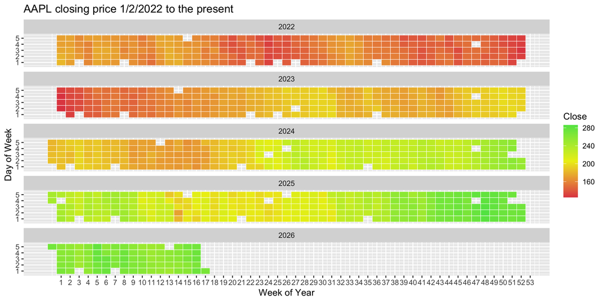

## Break a larger problem down

- First the data:

```r
stock_data <- read.csv("AAPL.csv", stringsAsFactors = FALSE)
head(stock_data)
```

```
          Date   Open   High    Low  Close Adj.Close     Volume
1 Apr 27, 2026 266.09 268.36 265.07 267.61    267.61 41,213,866
2 Apr 24, 2026 272.76 273.06 269.65 271.06    271.06 38,124,500
3 Apr 23, 2026 275.05 275.77 271.65 273.43    273.43 33,399,600
4 Apr 22, 2026 267.82 273.74 266.87 273.17    273.17 43,249,200
5 Apr 21, 2026 271.50 272.80 265.40 266.17    266.17 50,209,800
6 Apr 20, 2026 270.33 274.28 270.29 273.05    273.05 36,590,200
```

- The data is typically publicly available for commonly held stocks
- CSV is a commonly used format, we will eventually talk about Factors, but for now, don’t use them unless you must.

## Convert the character date to an R date

```r
options(width = 150)
stock_data$date_parsed <- as.Date(stock_data$Date, format = "%b %d, %Y")
stock_data$week <- as.integer(format(stock_data$date_parsed, "%U"))
stock_data$wday <- as.integer(format(stock_data$date_parsed, "%w"))
stock_data$year <- as.integer(format(stock_data$date_parsed, "%Y"))

head(stock_data)
```

```
          Date   Open   High    Low  Close Adj.Close     Volume date_parsed week wday year
1 Apr 27, 2026 266.09 268.36 265.07 267.61    267.61 41,213,866  2026-04-27   17    1 2026
2 Apr 24, 2026 272.76 273.06 269.65 271.06    271.06 38,124,500  2026-04-24   16    5 2026
3 Apr 23, 2026 275.05 275.77 271.65 273.43    273.43 33,399,600  2026-04-23   16    4 2026
4 Apr 22, 2026 267.82 273.74 266.87 273.17    273.17 43,249,200  2026-04-22   16    3 2026
5 Apr 21, 2026 271.50 272.80 265.40 266.17    266.17 50,209,800  2026-04-21   16    2 2026
6 Apr 20, 2026 270.33 274.28 270.29 273.05    273.05 36,590,200  2026-04-20   16    1 2026
```

## What is a date format in R?

- There are so many ways to represent a date, e.g., 1/1/1970, January 1, 1970, Jan 1 1970 etc. that formats are used to simplify and to construct dates.
- `strptime` means “string to parsed time” and its formats are commonly used:

```
%d = Day number of month
%a = Abbreviated weekday (Mon, Tue, Wed, etc.)
%A = Full weekday (Monday, Tuesday, etc.)
%w = Weekday number (0-6, Sunday is 0)
%u = Weekday number (1-7, Monday is 1)
%W = Week number (00-53, Monday is week start)
%U = Week number (00-53, Sunday is week start)
%m = Month number (e.g. 01, 02, 03, 04)
%b = Abbreviated month (Jan, Feb, etc.)
%B = Full month (January, February, etc.)
%y = 2-digit year (e.g. 89)
%Y = 4-digit year (e.g. 1989)
```

## ggplot aes() and geom()

- The two most important pieces, ggplot() with an aes() and then the geom()

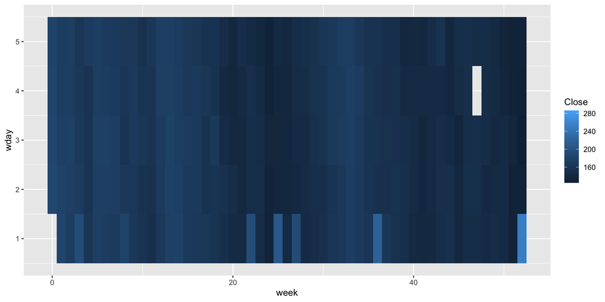

```r
options(width = 80)
ggplot(stock_data, aes(x = week, y = wday, fill = Close)) +
  geom_tile()
```

## it’s all there but unattractive

- color helps to make your visualizations more compelling

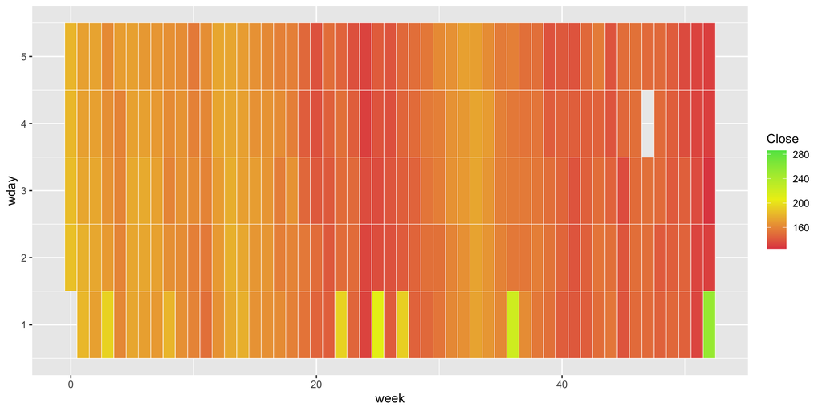

```r
ggplot(stock_data, aes(x = week, y = wday, fill = Close)) +
  geom_tile(color = "white") +
  scale_fill_gradientn(colors = c("#e14850", "#ecee12", "#5ee352"))
```

## Subset

- Breaking your data into smaller pieces helps reveal patterns
- Here, we “facet” to create subgroups within the data (and create a story)

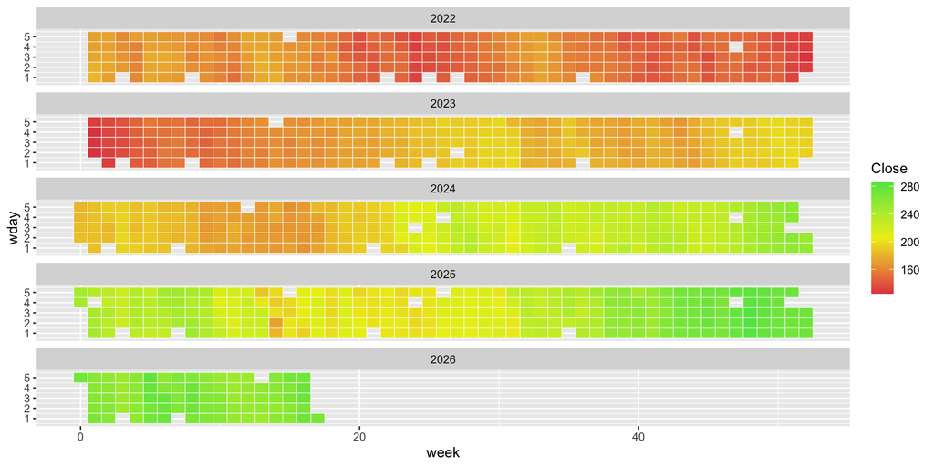

```r
ggplot(stock_data, aes(x = week, y = wday, fill = Close)) +
  geom_tile(color = "white") +
  scale_fill_gradientn(colors = c("#e14850", "#ecee12", "#5ee352")) +
  facet_wrap( ~ year, ncol = 1)
```

## Scaling and Labeling

- In ggplot, you `scale` to alter the limits and `labs()` allows labeling and titling

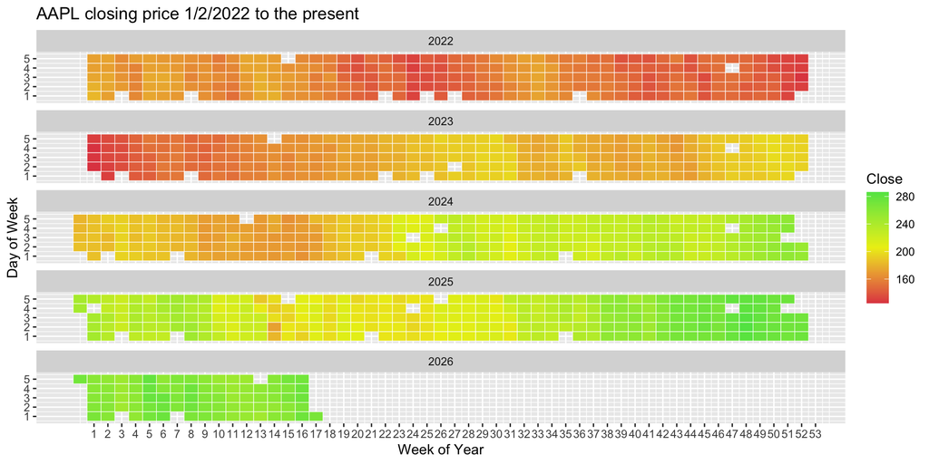

```r
ggplot(stock_data, aes(x = week, y = wday, fill = Close)) +
  geom_tile(color = "white") +
  scale_fill_gradientn(colors = c("#e14850", "#ecee12", "#5ee352")) +
  facet_wrap( ~ year, ncol = 1) +
  scale_x_continuous(breaks = 1:53) +
  labs(title = "AAPL closing price 1/2/2022 to the present",
       x = "Week of Year",
       y = "Day of Week")
```

## Example 2: Movies (where the aes()?)

- This is a simple dataset of movie rating by year of a movie’s release
- This example is all about colors and a reassurance about the aes() placement

```r
movies <- read_csv("movies.csv")
```

```
──────────────────────────────────────────────────────── Delimiter: "," chr
(2): title, mpaa dbl (23): ...1, year, length, budget, rating, votes, r1, r2,
r3, r4, r5, r6,...
```

```r
head(movies)
```

```
# A tibble: 6 × 25
   ...1 title      year length budget rating votes    r1    r2    r3    r4    r5
  <dbl> <chr>     <dbl>  <dbl>  <dbl>  <dbl> <dbl> <dbl> <dbl> <dbl> <dbl> <dbl>
1     1 $          1971    121     NA    6.4   348   4.5   4.5   4.5   4.5  14.5
2     2 $1000 a …  1939     71     NA    6      20   0    14.5   4.5  24.5  14.5
3     3 $21 a Da…  1941      7     NA    8.2     5   0     0     0     0     0
4     4 $40,000    1996     70     NA    8.2     6  14.5   0     0     0     0
5     5 $50,000 …  1975     71     NA    3.4    17  24.5   4.5   0    14.5  14.5
6     6 $pent      2000     91     NA    4.3    45   4.5   4.5   4.5  14.5  14.5
# ℹ 13 more variables: r6 <dbl>, r7 <dbl>, r8 <dbl>, r9 <dbl>, r10 <dbl>,
#   mpaa <chr>, Action <dbl>, Animation <dbl>, Comedy <dbl>, Drama <dbl>,
#   Documentary <dbl>, Romance <dbl>, Short <dbl>
```

## The final version

- I liked this one - but let’s learn about the steps to getting there
- need to `install.packages("hexbin") for this to run`

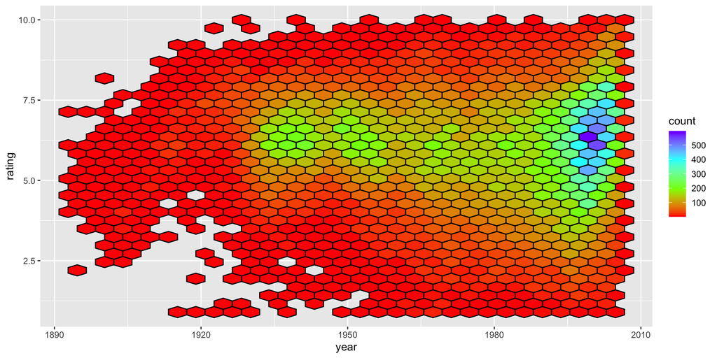

```r
library("hexbin")
ggplot(movies) +
  geom_hex(aes(x = year, y = rating), color = "black") +
  scale_fill_gradientn(colors = rainbow(4))
```

## What if I have no color?

- What if I removed all modified colors?

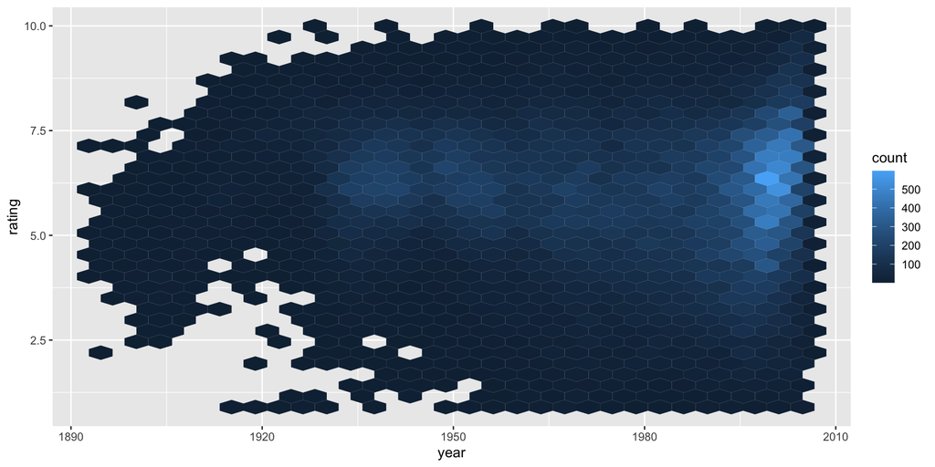

```r
ggplot(movies) +
  geom_hex(aes(x = year, y = rating))
```

## What if I add color?

- I use `scale_fill_gradientn()` as in the Apple example
- But instead of identifying my own colors, rainbow() is a function that generates colors along a rainbow and we specify the number of colors

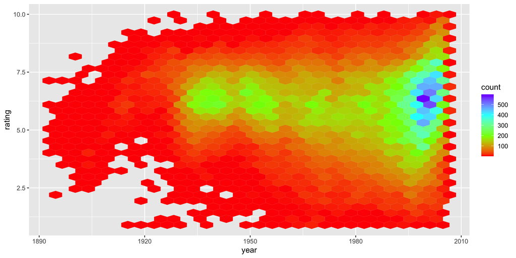

```r
ggplot(movies) +
  geom_hex(aes(x = year, y = rating)) +
  scale_fill_gradientn(colors = rainbow(4))
```

## What if I had moved the aes()

- Notice, no change, but we have only one `geom_` so it makes no difference

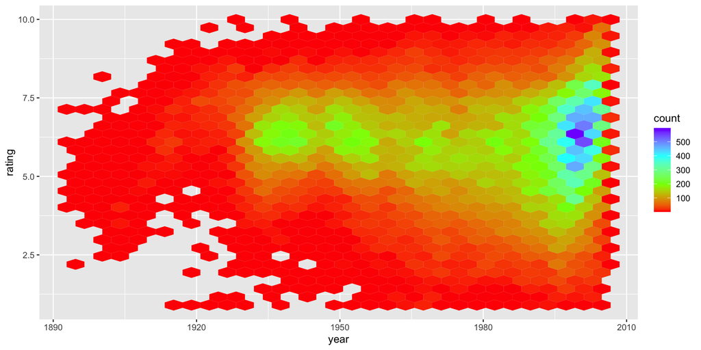

```r
ggplot(movies, aes(x = year, y = rating)) +
  geom_hex() +
  scale_fill_gradientn(colors = rainbow(4))
```

## Modifying the geom()

- Modifying the geom() only affects that specific geom()
- color = “black” is not really necessary but highlights the hexagons (teaching example, not production)

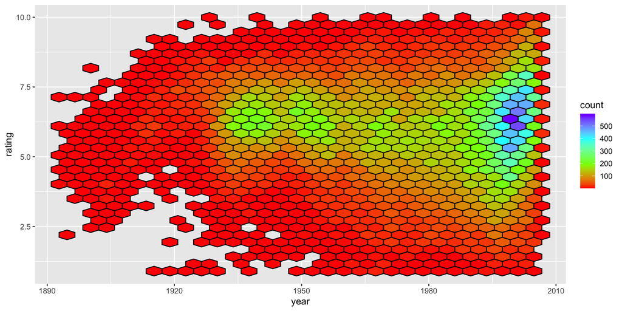

```r
ggplot(movies) +
  geom_hex(aes(x = year, y = rating), color = "black") +
  scale_fill_gradientn(colors = rainbow(4))
```

## Example 3: Multiple geoms

- Iris is the best example data
- Multiple ggplots use `library(gridExtra)`

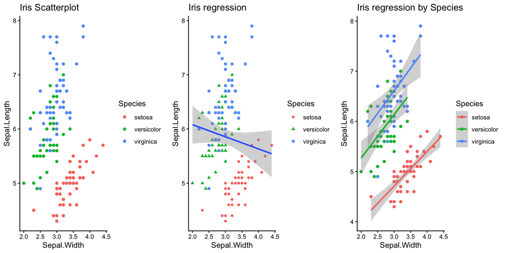

## Code: It’s all about the geom() & aes()

```r
plot1 <- ggplot(iris, aes(x = Sepal.Width, y = Sepal.Length, color = Species)) +
  geom_point() +  # one geom, doesn't matter where aes() is placed
  ggtitle("Iris Scatterplot") +
  theme_classic()

plot2 <- ggplot(iris, aes(x = Sepal.Width, y = Sepal.Length)) +
  geom_point(aes(color = Species, shape = Species)) +  # note color =
  geom_smooth(method = "lm") + # multiple geom, inherits aes() from ggplot()
  ggtitle("Iris regression") +
  theme_classic()

plot3 <- ggplot(iris, aes(x = Sepal.Width, y = Sepal.Length, color = Species)) +
  geom_point() + # note the location of color =, aes() in ggplot, so global
  geom_smooth(method = "lm") +
  ggtitle("Iris regression by Species") +
  theme_classic()

grid.arrange(plot1, plot2, plot3, nrow =1)
```

## ggplot() is worth the investment of time

- built in dataset diamonds

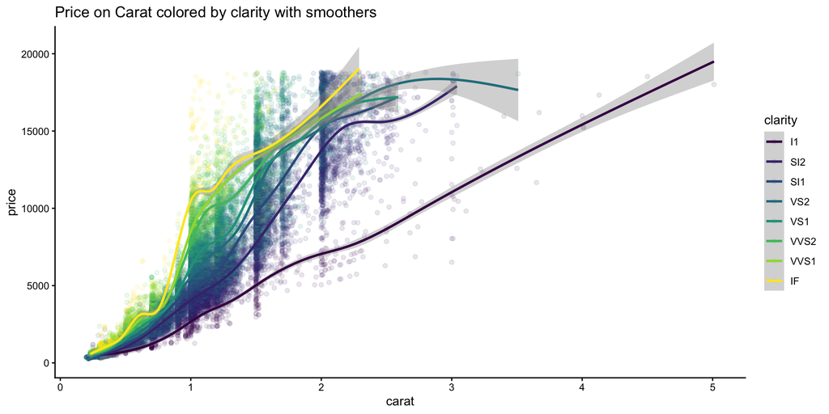

## Spotify bar plot?

- visualizations don’t necessarily have names like histogram or boxplot

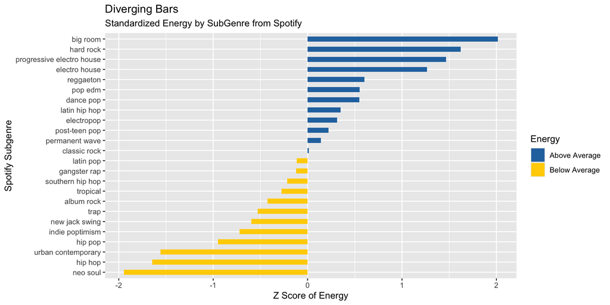

## spotify code

```r
# writing our own function called "z_scores" (next week)
z_scores <- function(x) {
  (x - mean(x, na.rm = TRUE)) / sd(x, na.rm = TRUE)
}

# load data and summarize it with aggregrate() from base R
load("spotify_songs.RData")
summary_spotify <- aggregate(cbind(track_popularity, danceability, energy) ~ playlist_subgenre,
                            data = spotify_songs, FUN = mean, na.rm = TRUE)
summary_spotify$Zenergy = z_scores(summary_spotify$energy) # a custom function - next week
summary_spotify$energy_type = ifelse(summary_spotify$Zenergy < 0, "below", "above") # vectorized
summary_spotify <- summary_spotify[order(summary_spotify$Zenergy),]   # order (sort) data frame by Zenergy
summary_spotify$playlist_subgenre = factor(summary_spotify$playlist_subgenre, summary_spotify$playlist_subgenre)
# covert to factor because of sorting issues -- another next week thing

# after a lot of data handling above, now we can plot
ggplot(data = summary_spotify,
            aes(x=playlist_subgenre, y=Zenergy, fill=energy_type)) +
  geom_bar(stat='identity', width=.5)  +
  scale_fill_manual(name="Energy",
                    labels = c("Above Average", "Below Average"),
                    values = c("above"="#2774AE", "below"="#FFD100")) +
  labs(subtitle="Standardized Energy by SubGenre from Spotify",
        title= "Diverging Bars",
        y = "Z Score of Energy",
        x = "Spotify Subgenre") +
  coord_flip() # y and x are reversed
```

## Activity #2 Attendance

### Please Greet Your Neighbor(s)

- You are pros.
- Reminder: You need at least one different neighbor each week for your attendance credit (only one photo required)
- Reminder: You cannot receive credit if it’s only you in the photo, please refrain from photoshopping/editing photos
- Reminder: You need to upload the photo for credit.
- Please try to greet & meet a new classmate, take a photograph.

# THERE IS NO MIDTERM

## But let’s review and fill in some gaps

### Research Workflow

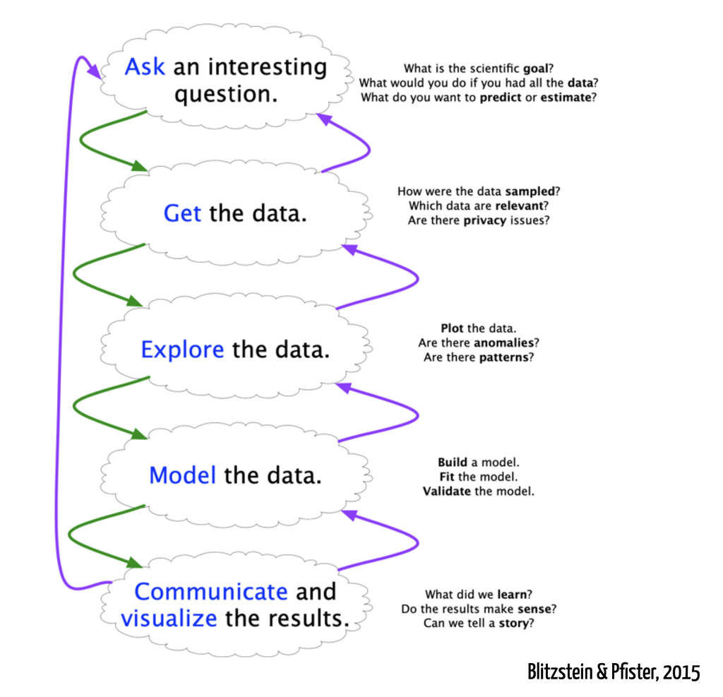

Research Workflow

- Here, it always starts with a question, pointing towards planning
- Acquire data (published, employment, experimental, surveyed)
- Explore/learn about the data
- (skip modeling, upper division or discipline specific mostly)
- Visualize and communicate (your exploration in Stats 20)

### Non-Research Workflow

[figure not shown]

Other Workflow

- The horizontal flow emphasizes connections
- More specialized: data ingestion/prep, data exploration, preprocessing/feature engineering, gathering insights from exploration.
- At a higher level (but perhaps in an assistive capacity), reporting, insight activation.

## Finding Data (Project 2)

- From your own work/research/projects
- From publicly available sources
  - [UCI ML Repository](https://archive.ics.uci.edu/datasets)
  - [Kaggle](https://www.kaggle.com/)
  - [Government](https://data.gov/)
  - [UN Data](https://data.un.org/)
- Don’t pay for data in Stats 20

# Get Data/Data Ingestion

## Creating Data in R: Vectors

- The most basic, a sequence with values of the same type. R will coerce values to the same type.
- Vectors in R are column vectors. Sometimes we need to create our own sequences.

```r
10:19 ## increments (or can decrement) by one
```

```
 [1] 10 11 12 13 14 15 16 17 18 19
```

```r
seq(from= 0, to= 100, by= 10)
```

```
 [1]   0  10  20  30  40  50  60  70  80  90 100
```

```r
seq(by = 10, to = 100, from = 0) # please don't do that to yourself or others, see the documentation
```

```
 [1]   0  10  20  30  40  50  60  70  80  90 100
```

```r
seq(0, 100, 10) # will also work, but it is not clear/it is confusing
```

```
 [1]   0  10  20  30  40  50  60  70  80  90 100
```

```r
c(TRUE, FALSE, TRUE, 8, 6, 7, 5, 3, "O", 9, 2.718282) # all are coerced to character
```

```
 [1] "TRUE"     "FALSE"    "TRUE"     "8"        "6"        "7"
 [7] "5"        "3"        "O"        "9"        "2.718282"
```

```r
.Machine$integer.max # check your max size
```

```
[1] 2147483647
```

## Sequences

- Can’t stress the value of constructing sequences enough

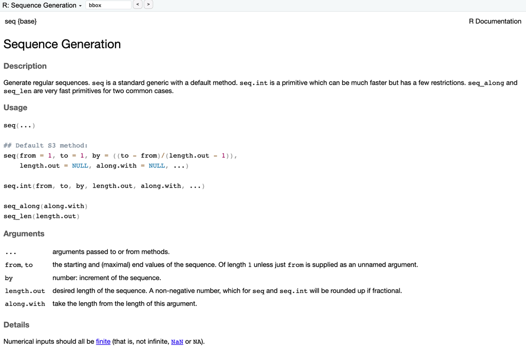

## (aside) Built-In Vectors

R provides built-in vectors for instruction, example, experimentation, etc.

```r
rivers
```

```
  [1]  735  320  325  392  524  450 1459  135  465  600  330  336  280  315  870
 [16]  906  202  329  290 1000  600  505 1450  840 1243  890  350  407  286  280
 [31]  525  720  390  250  327  230  265  850  210  630  260  230  360  730  600
 [46]  306  390  420  291  710  340  217  281  352  259  250  470  680  570  350
 [61]  300  560  900  625  332 2348 1171 3710 2315 2533  780  280  410  460  260
 [76]  255  431  350  760  618  338  981 1306  500  696  605  250  411 1054  735
 [91]  233  435  490  310  460  383  375 1270  545  445 1885  380  300  380  377
[106]  425  276  210  800  420  350  360  538 1100 1205  314  237  610  360  540
[121] 1038  424  310  300  444  301  268  620  215  652  900  525  246  360  529
[136]  500  720  270  430  671 1770
```

```r
str(rivers)
```

```
 num [1:141] 735 320 325 392 524 ...
```

```r
euro # a named vector
```

```
        ATS         BEF         DEM         ESP         FIM         FRF
  13.760300   40.339900    1.955830  166.386000    5.945730    6.559570
        IEP         ITL         LUF         NLG         PTE
   0.787564 1936.270000   40.339900    2.203710  200.482000
```

```r
str(euro)
```

```
 Named num [1:11] 13.76 40.34 1.96 166.39 5.95 ...
 - attr(*, "names")= chr [1:11] "ATS" "BEF" "DEM" "ESP" ...
```

```r
my_rivers <- rivers
str(my_rivers) # a copy
```

```
 num [1:141] 735 320 325 392 524 ...
```

## The “gets” `<-`

From Advanced R - the only place I’ve seen which really tries to explain why use a `<-` and not a “=” even though “=” does not create an error.

```
x <- 1:3
```

- The gets `<-` creating an object, a vector of values, c(1, 2, 3).
- And is binding c(1, 2, 3) to a name, x.
- c(1, 2, 3) doesn’t have a name; it’s actually the name that has a value

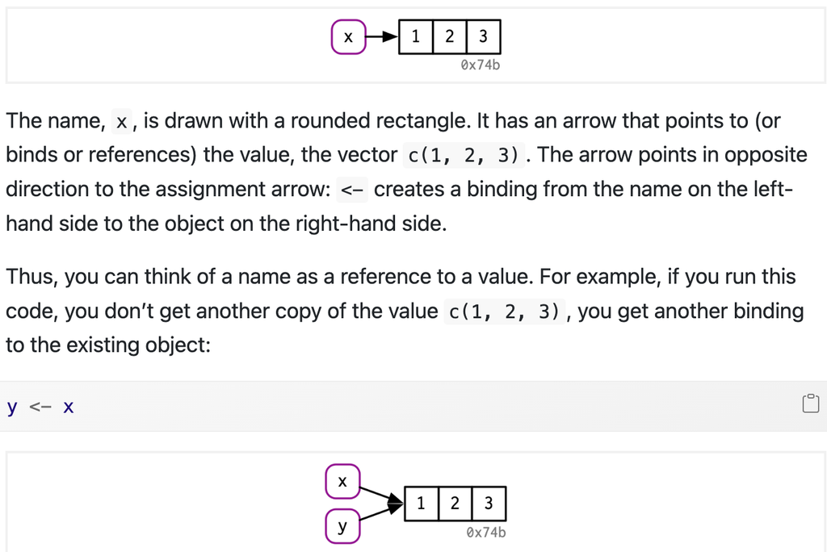

## Creating Data in R: Matrices

- Spend more time on this at the end of course, 2-D ordering of numbers typically.
- Whatever data type, it must all the same or is coerced to be the same.

```r
A <- matrix(1:12, nrow = 2)
A
```

```
     [,1] [,2] [,3] [,4] [,5] [,6]
[1,]    1    3    5    7    9   11
[2,]    2    4    6    8   10   12
```

```r
B <- as.matrix(iris[, 1:4])
head(B)
```

```
     Sepal.Length Sepal.Width Petal.Length Petal.Width
[1,]          5.1         3.5          1.4         0.2
[2,]          4.9         3.0          1.4         0.2
[3,]          4.7         3.2          1.3         0.2
[4,]          4.6         3.1          1.5         0.2
[5,]          5.0         3.6          1.4         0.2
[6,]          5.4         3.9          1.7         0.4
```

```r
dim(A)
```

```
[1] 2 6
```

```r
dim(B)
```

```
[1] 150   4
```

```r
length(A)
```

```
[1] 12
```

```r
length(B)
```

```
[1] 600
```

```r
is.matrix(A)
```

```
[1] TRUE
```

```r
is.matrix(B)
```

```
[1] TRUE
```

## Creating Data in R: Data Frames

- A 2-D collection of column vectors whose types do not need to be the same
- Note: their lengths do not need to be the same either - shorter vectors are RECYCLED to be the same length as the longest vector when combining the vectors.

```r
vec1 <- 1:10
vec2 <- LETTERS
vec3 <- c(TRUE, FALSE)
vec4 <- c(pi, exp(1), sqrt(2))

my_df <- cbind(vec1, vec2, vec3, vec4) |> data.frame() ## |> means "then"
head(my_df, n = 11)
```

```
   vec1 vec2  vec3             vec4
1     1    A  TRUE 3.14159265358979
2     2    B FALSE 2.71828182845905
3     3    C  TRUE  1.4142135623731
4     4    D FALSE 3.14159265358979
5     5    E  TRUE 2.71828182845905
6     6    F FALSE  1.4142135623731
7     7    G  TRUE 3.14159265358979
8     8    H FALSE 2.71828182845905
9     9    I  TRUE  1.4142135623731
10   10    J FALSE 3.14159265358979
11    1    K  TRUE 2.71828182845905
```

## A Note on Coercion

When you see functions with `as.` (also `as_`) in their names, think **coercion**

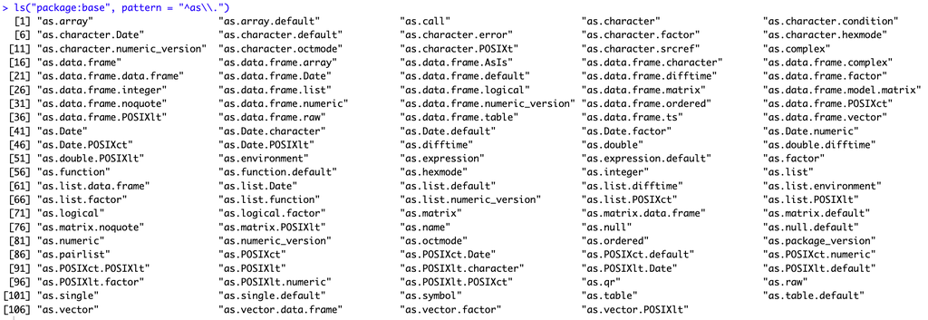

Coercion Functions in Base R

Of course you do not need to learn all of these, but what it does point to is just how common it is to coerce in R.

## Coercion Hierarchy

- This you should probably know, not for an exam necessarily, but as general rule in R.
- A nice explanation of the “why” [R Type Coercion](https://r-statistics.co/R-Type-Coercion.html)
- Short version - unlike other languages, R coerces behind your back, numbers become characters etc.
- We almost always see coercion occuring during the reading of data external to R (e.g., a csv file)
- Hierarchy (from “R in a Nutshell”)

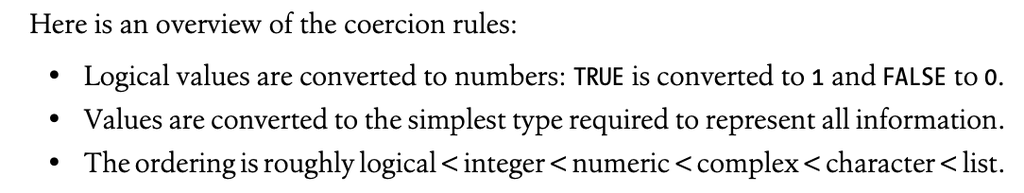

Coercion Rules

## Will I test on this?

- Probably. They are the building blocks. Vectors, Matrices, Data Frames, Lists.
- Recycling and Coercion are early features of the R Language.
- Example: Coercion exists because the original goal was to make everything data. Really.
- When importing data (coming up), important to know that coercion is occurring quietly.

## Reading Common Data Formats

### Base R

- `read.csv()` - comma separated values
- `read.delim()` - useful for tab separated (.tsv)
- `read.fwf()` (fixed width, very rare nowadays)
- `read.table()` (general purpose, many options)

### Others

- from the jsonlite package - `fromJson()`
- from the readxl package - `read_excel()`
- there are packages written just for reading Google Sheets but it is easy just to export it csv and then use `read.csv()` (See lecture 5 for an example)

## `load()` and `save()`

- R, like other languages has its own way of storing data and other objects for easy/fast retrieval
- Once data has been converted into an R object, it is practical to store it into something that R can read more quickly
- We can save our entire Global Environment using `save.image()` or we can save specific R objects using `save()`

```
# not run
x <- iris
y <- rivers
z <- pi
save.image("some_file_name.RData") # saves everything to "some_file_name.RData" in your working directory
save(x, y, file = "another_file_name.RData") # saves only x and y
file.exists("another_file_name.RData") # check to see if the file is there
file.info("another_file_name.RData") # get the info of your saved file
```

- we re-load them using `load("some_file_name.RData")` for example and objects x, y, and z will be found in the global environment.
- suggestion - follow a `load()` with an `ls()` or an objects`()` to verify what was loaded exists.
- Note: `save()` does not warn you if you are about to overwrite an existing copy.

## Checking

- We can be too trusting sometimes, always check the results before moving on
  - `ls()` and `objects()` - for the environment
  - `head()` and `tail()` - for specific data object
  - `str()` and `summary()` - displaying structure
  - `names()` - gets and sets the names of R objects like vectors
  - `dimnames()` - gets and sets dimension names, usually for matrix, array or data frames
  - `length()` - gets and sets the length of many R objects
  - `dim()` - gets and sets the dimensions, usually for matrix, array or data frames
  - `is()`, `class()`, `mode()`, `typeof()` - `is()` is informative, the others are best used in a computation programming setting

## Exact vs. Approximate

- Most numbers in R are stored as `doubles` (double-precision floating-point numbers). Because computers work in binary (base-2) and we work in decimal (base-10), certain fractions cannot be represented exactly
- Example: $1/3$ becomes $0.3333...$ and so this classic example:

```r
x <- 0.1 + 0.2
x
```

```
[1] 0.3
```

```r
x == 0.3
```

```
[1] FALSE
```

- Please do not use `==` to compare calculated decimals.
- Use `all.equal()`, which allows for tolerance.

```r
isTRUE(all.equal(x, 0.3))
```

```
[1] TRUE
```

```r
print(0.3, digits = 17)
```

```
[1] 0.29999999999999999
```

```r
print(x, digits = 17)
```

```
[1] 0.30000000000000004
```

## On Double-Precision Floating Point Numbers

### Double (about Capacity)

R uses 64 bits of memory exactly twice the 32-bit “single” precision that was common when R was being developed. It just means more room to store details.

### Precision (The Limit)

Even with that extra precision/storage, R double-precision numbers have about 15 to 17 significant digits. * R can store $1,234,567,890,123,456$ exactly, but if you try to add even a fraction to it, you see a problem * This is why we get the $0.1 + 0.2$ results. R is trying to fit an infinite fraction into a finite space.

### Floating Point (The Flexibility)

The decimal point isn’t “fixed” in one spot (like it is with dollars and cents). It can float to wherever it is needed to preserve those 17 digits of precision. The same numeric format can handle the scale of a galaxy or the scale of an atom without you needing to change your code.

## In R, Integers are Different

- Whole numbers (integers) **are** exact, up to a point.
- Integers are safe for `==`. This is why we use them for indexing or counting.
- If you plan to move into high-level statistics or big data, there is **Integer Overflow**.
- R’s integers are 32-bit. The maximum value is $2,147,483,647$ (we saw that earlier)
- When we try to calculate something larger (like a high-frequency count or a massive factorial), R will return `NA` with a warning or convert it to a `double`, losing precision in the process.
- In here, just know it can happen and always check your work.

## Try this on your machine

```r
x <- 1234567890123456.0
y <- 12345678901234567.0

format(x, digits = 17)
```

```
[1] "1234567890123456"
```

```r
format(y, digits = 17)
```

```
[1] "12345678901234568"
```

```r
z <- 1234567890123456.7
format(z, digits = 18)
```

```
[1] "1234567890123456.75"
```

```r
.Machine$double.xmax # check your max size
```

```
[1] 1.797693e+308
```

```r
.Machine$double.xmin # check your min size
```

```
[1] 2.225074e-308
```

```r
tiny <- .Machine$double.xmin
tiny/1e10 # try it you might be able to push past the posted limit, I got to 1e15 then zero
```

```
[1] 2.225074e-318
```

```r
big <- .Machine$double.xmax
big * 1.0000007 # goes to infinity much faster
```

```
[1] Inf
```

# If we have time

## Activity #3

- Prefer you do this in small groups or at least in a pair. Extra eyes can be useful.
- Simple math with vectors (Braun & Murdoch Chapter 2.2.9 Vector arithmetic)
- Create a vector of whole numbers of any length, assign it to an R object named “secret”
- Then perform some vector math on “secret”:

```
step1 <- secret + 5          # Add 5
step2 <- step1 * 2           # Double it
step3 <- step2 - 10          # Subtract 10
step4 <- step3 / 2           # Cut it in half

all.equal(step4, secret) # is this TRUE?  (it should be)
```

- Vector math is elementwise and utilizes recycling

## More Base R math functions

```
x <- c(10, 20)
result <- log(exp(sqrt(x^2)))
all.equal(result, x) # should be
```

- suppose you were to write x <- c(-10, 10), what happens? how might you fix it?
- hint: look for another common math function in base R if you type

```
?S4groupGeneric # you will see all of the newer and original ones
```

- if you want to know why its result looks the way it does, you could check help(“all.equal”) but in a sentence, if something is not equal, all.equal() will attempt to tell you how different it is (or they are)

# Extracting Information from Data Structures

## Subsetting, using `[` - Data Frame

- The single bracket works on any data structure. The key is understanding what it is being applied to (input) and what is the result (output).
- This example involves a **data frame**, recall `df[row(s), column(s)]` will extract specific rows and columns if given them by name or by position (number or index)

```r
EQ2025 <- read.table("https://service.scedc.caltech.edu/ftp/catalogs/SCEC_DC/2025.catalog",
                          col.names = c("DATE", "TIME", "EVENT_TYPE", "GT", "MAG","MAGTYPE","LAT",
                                        "LON", "DEPTH", "QUALITY", "EVENT_ID", "Num_Phases",
                                        "Num_Grams"))
str(EQ2025)
```

```
'data.frame':   16818 obs. of  13 variables:
 $ DATE      : chr  "2025/01/01" "2025/01/01" "2025/01/01" "2025/01/01" ...
 $ TIME      : chr  "01:00:56.92" "01:16:28.99" "01:30:49.87" "01:54:51.66" ...
 $ EVENT_TYPE: chr  "eq" "eq" "eq" "eq" ...
 $ GT        : chr  "l" "l" "l" "l" ...
 $ MAG       : num  0.59 1.21 0.6 1.06 0.57 0.96 0.9 0.58 0.85 0.51 ...
 $ MAGTYPE   : chr  "l" "l" "l" "l" ...
 $ LAT       : num  33.3 34 34.1 35.5 33.5 ...
 $ LON       : num  -116 -117 -118 -118 -117 ...
 $ DEPTH     : num  3.3 13.4 12.2 8.6 5.9 10.2 8.8 7.9 4.9 10.9 ...
 $ QUALITY   : chr  "A" "A" "A" "A" ...
 $ EVENT_ID  : int  40831087 40831095 40831103 40831111 40831119 40831127 40831135 40831151 40831159 40831167 ...
 $ Num_Phases: int  7 94 18 49 58 96 74 41 35 44 ...
 $ Num_Grams : int  1005 2122 1834 1442 1125 1472 1194 1106 1557 1880 ...
```

## Subsetting, using `[` - Specifying columns

- With a data frame, we could use it to extract single vectors or multiple vectors, the single vector result will be a vector, multiple vectors return a data frame.

```r
mag1 <- EQ2025[ , 5] # column 5, all rows
mag2 <- EQ2025[ , "MAG"] # name of the column, all rows
paste("Compare mag1 and mag2", all.equal(mag1, mag2))
```

```
[1] "Compare mag1 and mag2 TRUE"
```

```r
is(mag1)
```

```
[1] "numeric"      "vector"       "index"        "replValue"    "numLike"
[6] "number"       "atomicVector"
```

```r
mag_qual1 <- EQ2025[ , c(5, 10)]  # columns 5 and 10, all rows
mag_qual2 <- EQ2025[ , c("MAG", "QUALITY")]
mag_qual3 <- EQ2025[ , c("QUALITY", "MAG")] # switched, you can order things the way you want
paste("Are mag_qual1 and mag_qual2 the same?", all.equal(mag_qual1, mag_qual2))
```

```
[1] "Are mag_qual1 and mag_qual2 the same? TRUE"
```

```r
paste("Are mag_qual2 and mag_qual3 the same?", all.equal(mag_qual2, mag_qual3))
```

```
[1] "Are mag_qual2 and mag_qual3 the same? Names: 2 string mismatches"
[2] "Are mag_qual2 and mag_qual3 the same? Component 1: Modes: numeric, character"
[3] "Are mag_qual2 and mag_qual3 the same? Component 1: target is numeric, current is character"
[4] "Are mag_qual2 and mag_qual3 the same? Component 2: Modes: character, numeric"
[5] "Are mag_qual2 and mag_qual3 the same? Component 2: target is character, current is numeric"
```

```r
is(mag_qual2)
```

```
[1] "data.frame" "list"       "oldClass"   "vector"
```

## Subsetting, using `[` - Specifying rows

```r
mag3 <- EQ2025[EQ2025$MAG > 3, ] # The row values for the MAG column must be > 3, all columns

mag3safer <- EQ2025[which(EQ2025$MAG > 3), ] # name of the column, all rows

all.equal(mag3, mag3safer) # result is the same
```

```
[1] TRUE
```

```r
which(EQ2025$MAG > 3)
```

```
  [1]   273   367   475   557   678   878   902  1624  1636  1656  1746  1777
 [13]  1784  1793  1877  2040  2134  2342  2432  2565  2595  2724  2849  2986
 [25]  3391  3453  3475  3839  3902  3911  3969  4172  4231  4243  4343  4669
 [37]  4799  5248  5395  5670  6180  6608  6899  7200  7462  8602  8792  8793
 [49]  8826  8831  8858  9065  9286  9550  9865  9866  9992  9993 10120 10239
 [61] 10255 10274 10310 10328 10329 10333 10336 10528 10750 10788 10809 11679
 [73] 11943 12065 12121 12160 12295 12358 12362 12556 13054 13145 13203 13214
 [85] 13220 13932 13961 13997 14073 14082 14314 14794 14849 14879 14892 15144
 [97] 15186 15191 15192 15447 15648 15698 15823 15938 16076 16094 16105 16118
[109] 16181 16226
```

- The result of EQ2025$MAG > 3 gives us a vector of TRUE and FALSE for all rows
- which() will give us the exact row indices, it can be safer when you are using `==` or have NA, NaN values

## Using the `$`

- We can use it to extract vectors by their names.
- It is a little more readable

```r
MAG <- EQ2025$MAG # creates a vector unassociated with the data frame, free floating, can be confusing

## a better application
fivenum(EQ2025$MAG) # extracting a specific vector for analysis
```

```
[1] 0.00 0.71 0.99 1.34 5.21
```

```r
## you could extract further
fivenum(EQ2025$MAG[EQ2025$MAG > 3]) # vector EQ2025$MAG extract those MAG > 3
```

```
[1] 3.01 3.12 3.29 3.57 5.21
```

```r
## and use different information
table(EQ2025$QUALITY[EQ2025$MAG > 3]) # vector EQ2025$QUALITY extract those with MAG > 3
```

```
  A   B   C   D
103   1   4   2
```